# Practical Machine Learning Project

### Background

Using devices such as Jawbone Up, Nike FuelBand, and Fitbit it is now possible to collect a large amount of data about personal activity relatively inexpensively. These type of devices are part of the quantified self movement - a group of enthusiasts who take measurements about themselves regularly to improve their health, to find patterns in their behavior, or because they are tech geeks. One thing that people regularly do is quantify how much of a particular activity they do, but they rarely quantify how well they do it. In this project, your goal will be to use data from accelerometers on the belt, forearm, arm, and dumbell of 6 participants. They were asked to perform barbell lifts correctly and incorrectly in 5 different ways. More information is available from the website here: http://groupware.les.inf.puc-rio.br/har (see the section on the Weight Lifting Exercise Dataset).

### The Data

The training data for this project are available here: https://d396qusza40orc.cloudfront.net/predmachlearn/pml-training.csv  
The test data are available here: https://d396qusza40orc.cloudfront.net/predmachlearn/pml-testing.csv

The data for this project come from this source: http://groupware.les.inf.puc-rio.br/har

### Loading and processing the Data

We first load the training and testing files into R and take a glance at the data.

After looking at the data we notice that a lot of variables have a large amount of or consist entirely of ‘NA’ values. We also notice that several of the variables have nothing to do with the movement we are interested in. So, we take steps to remove all the variables with mostly NA’s and remove the first 7 variables, as they have no relation to movement.

Once that is done we split the processed data into two parts to begin some analysis.

```r
trainingRNA <- training[ , colSums(is.na(training)) == 0]
Final.training <- trainingRNA[,-c(1:7)]

inTrain <- createDataPartition(Final.training$classe, p=0.7, list = FALSE)
train <- Final.training[inTrain,]
test <- Final.training[-inTrain,]
```

### The R-Part Model

To start our analysis we set a seed and fit the training data to an R-part model using the train function in the caret package. We then create a initial plot to see how the model looks. As well as take a glance at the model. We expect the out of sample error to be less than 0.05%.

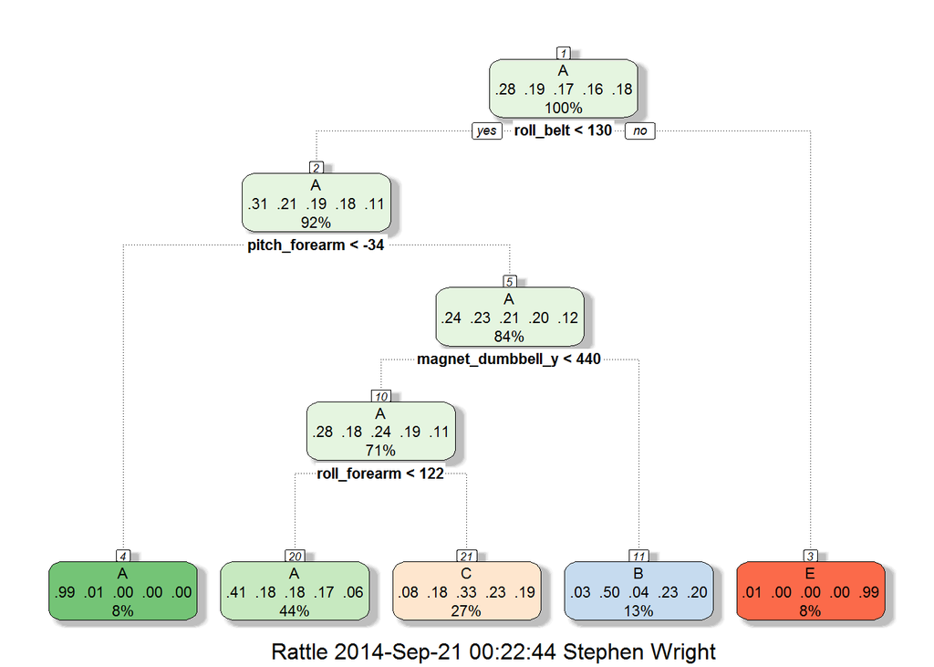

```r
set.seed(505)
model.Rpart <- train(classe ~., method ='rpart', data = train)
fancyRpartPlot(model.Rpart$finalModel)
```

```r
model.Rpart
```

```
## CART
##
## 13737 samples
##    52 predictor
##     5 classes: 'A', 'B', 'C', 'D', 'E'
##
## No pre-processing
## Resampling: Bootstrapped (25 reps)
##
## Summary of sample sizes: 13737, 13737, 13737, 13737, 13737, 13737, ...
##
## Resampling results across tuning parameters:
##
##   cp    Accuracy  Kappa  Accuracy SD  Kappa SD
##   0.03  0.5       0.38   0.03         0.04
##   0.06  0.4       0.19   0.06         0.10
##   0.11  0.3       0.06   0.04         0.06
##
## Accuracy was used to select the optimal model using  the largest value.
## The final value used for the model was cp = 0.03387.
```

Next we predict the values of the test set using our model, using the predict function. We also test the prediction against the correct test values using the confusionMatrix function.

```r
pred.Rpart <- predict(model.Rpart, test)
confusionMatrix(pred.Rpart, test$classe)
```

```
## Confusion Matrix and Statistics
##
##           Reference
## Prediction    A    B    C    D    E
##          A 1539  444  472  436  170
##          B   21  396   37  159  129
##          C  113  299  517  369  279
##          D    0    0    0    0    0
##          E    1    0    0    0  504
##
## Overall Statistics
##
##                Accuracy : 0.502
##                  95% CI : (0.489, 0.515)
##     No Information Rate : 0.284
##     P-Value [Acc > NIR] : <2e-16
##
##                   Kappa : 0.35
##  Mcnemar's Test P-Value : NA
##
## Statistics by Class:
##
##                      Class: A Class: B Class: C Class: D Class: E
## Sensitivity             0.919   0.3477   0.5039    0.000   0.4658
## Specificity             0.639   0.9271   0.7818    1.000   0.9998
## Pos Pred Value          0.503   0.5337   0.3278      NaN   0.9980
## Neg Pred Value          0.952   0.8555   0.8818    0.836   0.8926
## Prevalence              0.284   0.1935   0.1743    0.164   0.1839
## Detection Rate          0.262   0.0673   0.0879    0.000   0.0856
## Detection Prevalence    0.520   0.1261   0.2680    0.000   0.0858
## Balanced Accuracy       0.779   0.6374   0.6429    0.500   0.7328
```

As we can see from the confusion matrix we have a fairly low accuracy rate with this model and our error rate expectation was off. Thus, we decide to try another approach to a model.

### The Random Forest Model

```r
set.seed(506)
model.Rforest <- randomForest(classe~., mtry = 30, ntree =100, keep.forest = TRUE, importance = TRUE, proximity = TRUE, data = train)
model.Rforest
```

```
##
## Call:
##  randomForest(formula = classe ~ ., data = train, mtry = 30, ntree = 100,      keep.forest = TRUE, importance = TRUE, proximity = TRUE)
##                Type of random forest: classification
##                      Number of trees: 100
## No. of variables tried at each split: 30
##
##         OOB estimate of  error rate: 0.9%
## Confusion matrix:
##      A    B    C    D    E class.error
## A 3896    8    2    0    0    0.002560
## B   24 2624    9    1    0    0.012792
## C    0   14 2368   14    0    0.011686
## D    1    3   27 2218    3    0.015098
## E    0    1    7   10 2507    0.007129
```

```r
pred.Rforest <- predict(model.Rforest, test)
confusionMatrix(pred.Rforest, test$classe)
```

```
## Confusion Matrix and Statistics
##
##           Reference
## Prediction    A    B    C    D    E
##          A 1674   12    0    0    0
##          B    0 1120    6    0    0
##          C    0    7 1017   14    1
##          D    0    0    3  950    5
##          E    0    0    0    0 1076
##
## Overall Statistics
##
##                Accuracy : 0.992
##                  95% CI : (0.989, 0.994)
##     No Information Rate : 0.284
##     P-Value [Acc > NIR] : <2e-16
##
##                   Kappa : 0.99
##  Mcnemar's Test P-Value : NA
##
## Statistics by Class:
##
##                      Class: A Class: B Class: C Class: D Class: E
## Sensitivity             1.000    0.983    0.991    0.985    0.994
## Specificity             0.997    0.999    0.995    0.998    1.000
## Pos Pred Value          0.993    0.995    0.979    0.992    1.000
## Neg Pred Value          1.000    0.996    0.998    0.997    0.999
## Prevalence              0.284    0.194    0.174    0.164    0.184
## Detection Rate          0.284    0.190    0.173    0.161    0.183
## Detection Prevalence    0.286    0.191    0.177    0.163    0.183
## Balanced Accuracy       0.999    0.991    0.993    0.992    0.997
```

### Final Results

```r
pred.Final <- predict(model.Rforest, Ptesting)
pred.Final
```

```
##  1  2  3  4  5  6  7  8  9 10 11 12 13 14 15 16 17 18 19 20
##  B  A  B  A  A  E  D  B  A  A  B  C  B  A  E  E  A  B  B  B
## Levels: A B C D E
```

Our model correctly predicts the test cases.